# IE 582-HW 1

Kadir Ahmet Aksu

17 11 2020

```r
library(data.table)
library(chron)
library(ellipsis)
library(forecast)
library(xts)
library(zoo)
library(stats)
library(dplyr)
```

```r
library(corrr)
library(corrplot)
setwd("C:/Users/kadir/OneDrive/Masaüstü")

pl2018<-read.csv("E0 (3).csv", sep = ",")
pl2019<-read.csv("E0 (2).csv", sep = ",")
pl2020<-read.csv("E0 (4).csv", sep = ",")
newpl2018<-pl2018[,1:56]
newpl2019<-pl2019[,1:56]
newpl2020<-pl2020[,1:56]

newpl2018<-data.table(newpl2018)
newpl2019<-data.table(newpl2019)
newpl2020<-data.table(newpl2020)
```

## TASK 1.1

```r
Homescore<-1:828
Homescore[1:380]<-newpl2018$FTHG
Homescore[381:760]<-newpl2019$FTHG
Homescore[761:828]<-newpl2020$FTHG

Awayscore<-1:828
Awayscore[1:380]<-newpl2018$FTAG
Awayscore[381:760]<-newpl2019$FTAG
Awayscore[761:828]<-newpl2020$FTAG

Diff<-1:828
Diff<-Homescore-Awayscore

sort(unique(Homescore))
```

```
## [1] 0 1 2 3 4 5 6 7 8
```

```r
homebreaks<-0:9-0.5

sort(unique(Awayscore))
```

```
## [1] 0 1 2 3 4 5 6 9
```

```r
awaybreaks<-0:10-0.5

sort(unique(Diff))
```

```
##  [1] -9 -5 -4 -3 -2 -1  0  1  2  3  4  5  6  8
```

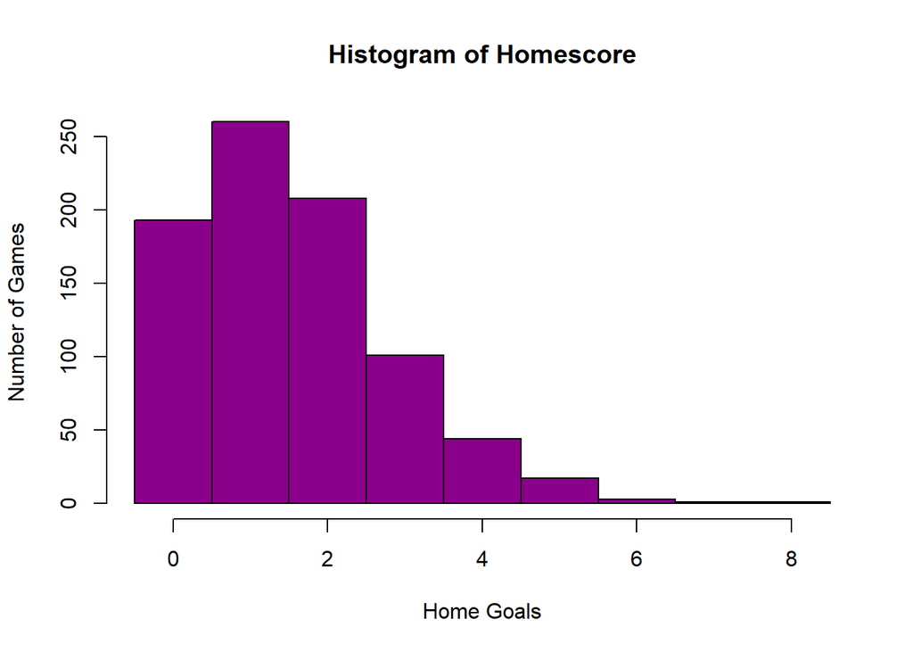

```r
diffbreaks<--9:9-0.5



hist(Homescore, breaks=homebreaks,xlab="Home Goals",
     ylab="Number of Games",
     col="darkmagenta",
)
```

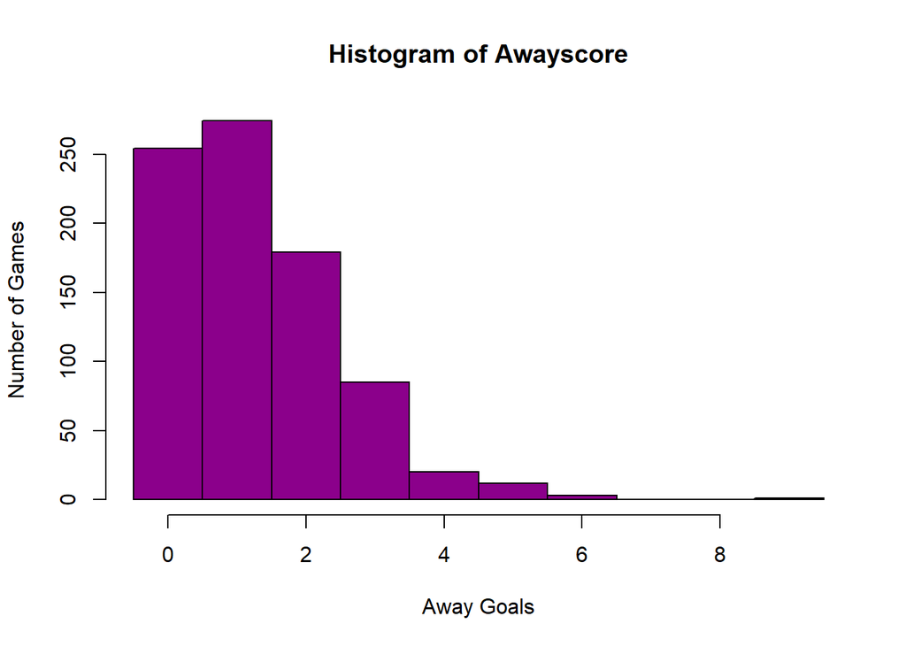

```r
hist(Awayscore,breaks=awaybreaks, xlab="Away Goals",
     ylab="Number of Games",
     col="darkmagenta",
)
```

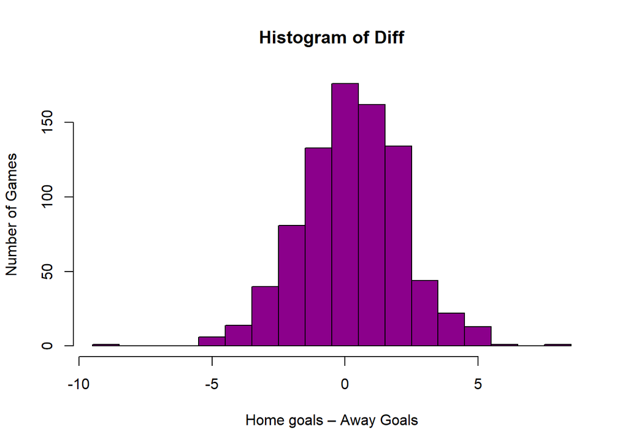

```r
hist(Diff,breaks=diffbreaks, xlab="Home goals – Away Goals",
     ylab="Number of Games",
     col="darkmagenta",
)
```

## TASK 1.2

##I added the Poisson Curve plots on the histograms of “Home Score (goals)” and “Away Score (goals)” which can be seen below. The results are, as expected, the distribution of goals for both, away and home goals, indeed really close to Poisson distribution curves.

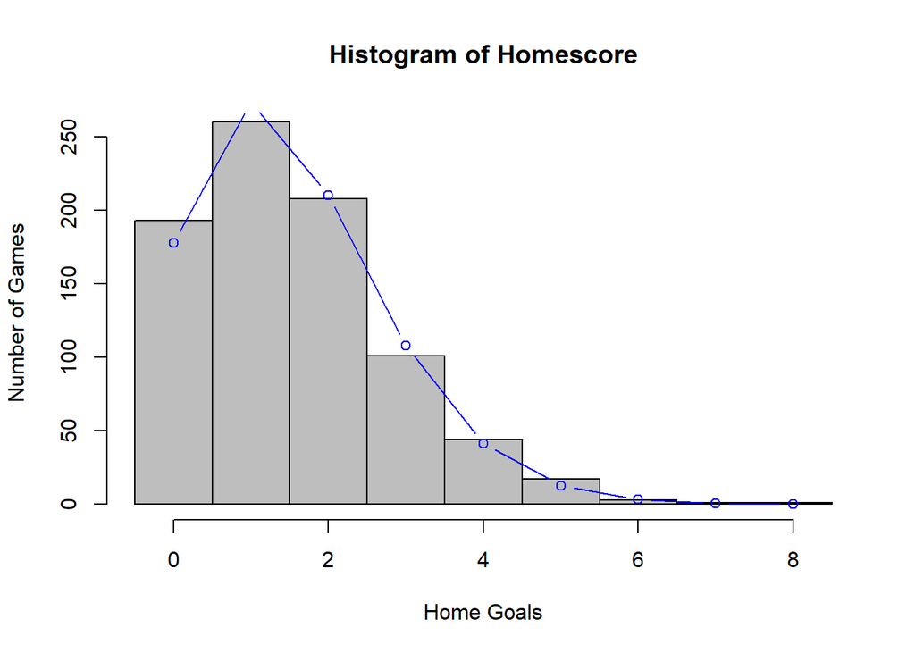

```r
homerate<-mean(Homescore)
awayrate<-mean(Awayscore)
homex<-sort(unique(Homescore))
awayx<-sort(unique(Awayscore))


hist(Homescore,breaks=homebreaks, xlab="Home Goals",
     ylab="Number of Games",
     col="gray",
)

points(homex,dpois(homex,homerate)*828,type="b",col="blue")
```

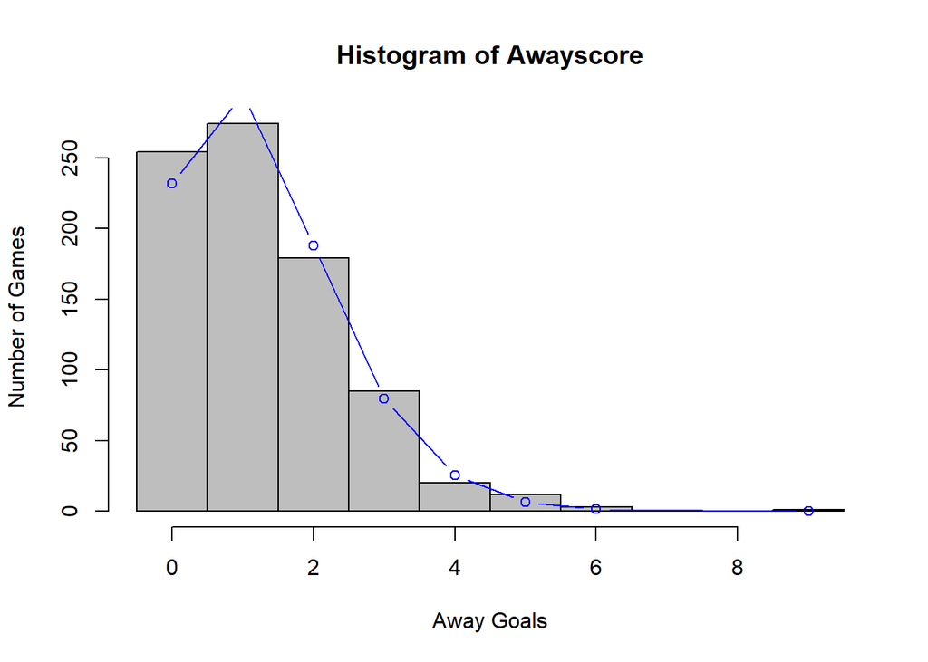

```r
hist(Awayscore,breaks=awaybreaks, xlab="Away Goals",
     ylab="Number of Games",
     col="gray",
)


points(awayx,dpois(awayx,awayrate)*828,type="b",col="blue")
```

## TASK 2 PREPARATION

```r
newpl2018[,MatchResult:=ifelse(FTHG>FTAG,'home',ifelse(FTHG==FTAG,'draw','away'))]
newpl2019[,MatchResult:=ifelse(FTHG>FTAG,'home',ifelse(FTHG==FTAG,'draw','away'))]
newpl2020[,MatchResult:=ifelse(FTHG>FTAG,'home',ifelse(FTHG==FTAG,'draw','away'))]

Result<-1:828
Result[1:380]<-newpl2018$MatchResult
Result[381:760]<-newpl2019$MatchResult
Result[761:828]<-newpl2020$MatchResult

RedCardH<-1:828
RedCardH[1:380]<-newpl2018$HR
RedCardH[381:760]<-newpl2019$HR
RedCardH[761:828]<-newpl2020$HR


RedCardA<-1:828
RedCardA[1:380]<-newpl2018$AR
RedCardA[381:760]<-newpl2019$AR
RedCardA[761:828]<-newpl2020$AR
```

## TASK 2 FOR BET365

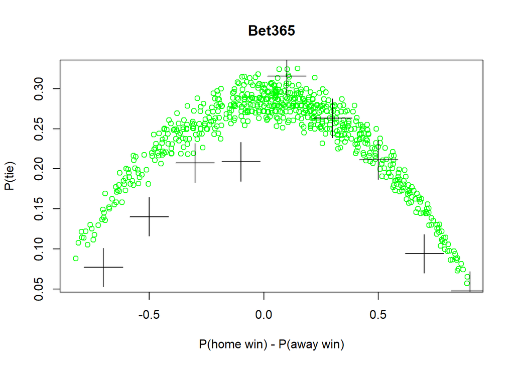

```r
Bet365H.odd1<-1:828
Bet365H.odd1[1:380]<-newpl2018$B365H
Bet365H.odd1[381:760]<-newpl2019$B365H
Bet365H.odd1[761:828]<-newpl2020$B365H

Bet365D.oddx<-1:828
Bet365D.oddx[1:380]<-newpl2018$B365D
Bet365D.oddx[381:760]<-newpl2019$B365D
Bet365D.oddx[761:828]<-newpl2020$B365D

Bet365A.odd2<-1:828
Bet365A.odd2[1:380]<-newpl2018$B365A
Bet365A.odd2[381:760]<-newpl2019$B365A
Bet365A.odd2[761:828]<-newpl2020$B365A

Bet365H.ph<-1:828
Bet365H.ph[1:380]<-1/newpl2018$B365H
Bet365H.ph[381:760]<-1/newpl2019$B365H
Bet365H.ph[761:828]<-1/newpl2020$B365H

Bet365D.px<-1:828
Bet365D.px[1:380]<-1/newpl2018$B365D
Bet365D.px[381:760]<-1/newpl2019$B365D
Bet365D.px[761:828]<-1/newpl2020$B365D

Bet365A.pa<-1:828
Bet365A.pa[1:380]<-1/newpl2018$B365A
Bet365A.pa[381:760]<-1/newpl2019$B365A
Bet365A.pa[761:828]<-1/newpl2020$B365A

NormBet365H<-Bet365H.ph/(Bet365H.ph+Bet365D.px+Bet365A.pa)
NormBet365D<-Bet365D.px/(Bet365H.ph+Bet365D.px+Bet365A.pa)
NormBet365A<-Bet365A.pa/(Bet365H.ph+Bet365D.px+Bet365A.pa)


Bet365<-data.table(Homescore,Awayscore,Result,Bet365H.odd1,Bet365A.odd2,Bet365D.oddx,Bet365H.ph,Bet365A.pa,Bet365D.px,NormBet365H,NormBet365A,NormBet365D,RedCardH,RedCardA)

Bet365[,diff:=NormBet365H-NormBet365A]

br<-(-5:5)/5
bucketBet365<-cut(Bet365$diff,breaks=br,labels=1:10)
Bet365[,bucket:=bucketBet365]

plot(Bet365$NormBet365H-Bet365$NormBet365A,Bet365$NormBet365D,col="green",main="Bet365",xlab="P(home win) - P(away win)",ylab="P(tie)")

plot(Bet365$NormBet365H-Bet365$NormBet365A,Bet365$NormBet365D,col="green",main="Bet365",xlab="P(home win) - P(away win)",ylab="P(tie)")


bet365draws<-1:10
for(i in 1:10)
  bet365draws[i]<-sum(Bet365[bucket==i]$Result=="draw",na.rm=TRUE)


bet365sum<-1:10
for(i in 1:10)
  bet365sum[i]<-sum(!is.na(Bet365[bucket==i]$Result))


bet365p<-bet365draws/bet365sum
y<-c(-0.9,-0.7,-0.5,-0.3,-0.1,0.1,0.3,0.5,0.7,0.9)
points(y,bet365p,pch=3,cex = 5)
```

## TASK 2 FOR BETANDWIN

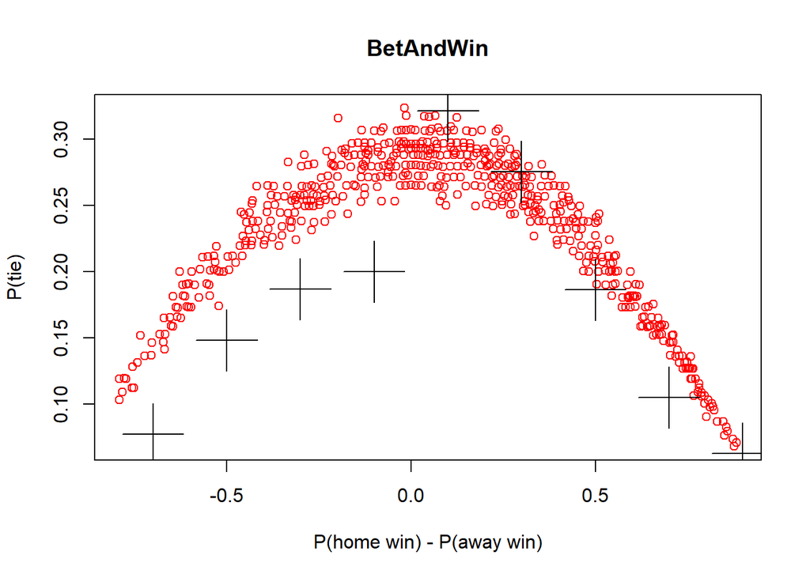

```r
BWH.odd1<-1:828
BWH.odd1[1:380]<-newpl2018$BWH
BWH.odd1[381:760]<-newpl2019$BWH
BWH.odd1[761:828]<-newpl2020$BWH

BWD.oddx<-1:828
BWD.oddx[1:380]<-newpl2018$BWD
BWD.oddx[381:760]<-newpl2019$BWD
BWD.oddx[761:828]<-newpl2020$BWD

BWA.odd2<-1:828
BWA.odd2[1:380]<-newpl2018$BWA
BWA.odd2[381:760]<-newpl2019$BWA
BWA.odd2[761:828]<-newpl2020$BWA

BWH.ph<-1:828
BWH.ph[1:380]<-1/newpl2018$BWH
BWH.ph[381:760]<-1/newpl2019$BWH
BWH.ph[761:828]<-1/newpl2020$BWH

BWD.px<-1:828
BWD.px[1:380]<-1/newpl2018$BWD
BWD.px[381:760]<-1/newpl2019$BWD
BWD.px[761:828]<-1/newpl2020$BWD

BWA.pa<-1:828
BWA.pa[1:380]<-1/newpl2018$BWA
BWA.pa[381:760]<-1/newpl2019$BWA
BWA.pa[761:828]<-1/newpl2020$BWA

NormBWH<-BWH.ph/(BWH.ph+BWD.px+BWA.pa)
NormBWD<-BWD.px/(BWH.ph+BWD.px+BWA.pa)
NormBWA<-BWA.pa/(BWH.ph+BWD.px+BWA.pa)


BW<-data.table(Homescore,Awayscore,Result,BWH.odd1,BWA.odd2,BWD.oddx,BWH.ph,BWA.pa,BWD.px,NormBWH,NormBWA,NormBWD,RedCardH,RedCardA)

BW[,diff:=NormBWH-NormBWA]

br<-(-5:5)/5
bucketBW<-cut(BW$diff,breaks=br,labels=1:10)
BW[,bucket:=bucketBW]

plot(BW$NormBWH-BW$NormBWA,BW$NormBWD,col="red",main="BetAndWin",xlab="P(home win) - P(away win)",ylab="P(tie)")
plot(BW$NormBWH-BW$NormBWA,BW$NormBWD,col="red",main="BetAndWin",xlab="P(home win) - P(away win)",ylab="P(tie)")


bwdraws<-1:10
for(i in 1:10)
  bwdraws[i]<-sum(BW[bucket==i]$Result=="draw",na.rm=TRUE)


bwsum<-1:10
for(i in 1:10)
  bwsum[i]<-sum(!is.na(BW[bucket==i]$Result))


bwp<-bwdraws/bwsum
y<-c(-0.9,-0.7,-0.5,-0.3,-0.1,0.1,0.3,0.5,0.7,0.9)
points(y,bwp,pch=3,cex = 5)
```

## TASK 2 FOR PINNACLE

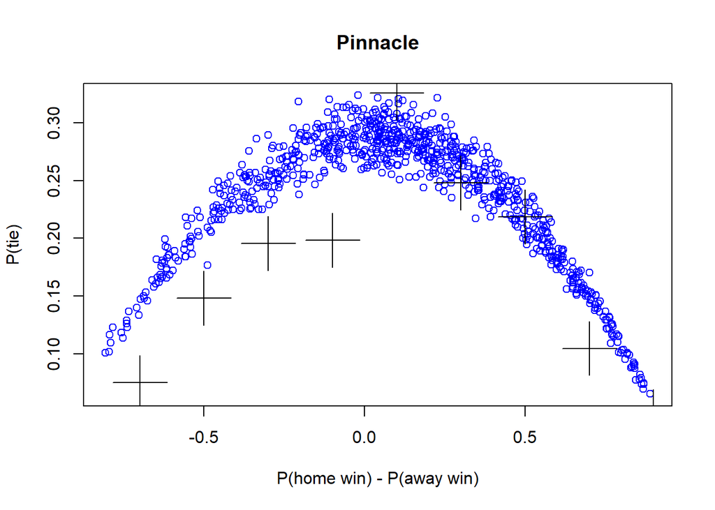

```r
PSH.odd1<-1:828
PSH.odd1[1:380]<-newpl2018$PSH
PSH.odd1[381:760]<-newpl2019$PSH
PSH.odd1[761:828]<-newpl2020$PSH

PSD.oddx<-1:828
PSD.oddx[1:380]<-newpl2018$PSD
PSD.oddx[381:760]<-newpl2019$PSD
PSD.oddx[761:828]<-newpl2020$PSD

PSA.odd2<-1:828
PSA.odd2[1:380]<-newpl2018$PSA
PSA.odd2[381:760]<-newpl2019$PSA
PSA.odd2[761:828]<-newpl2020$PSA

PSH.ph<-1:828
PSH.ph[1:380]<-1/newpl2018$PSH
PSH.ph[381:760]<-1/newpl2019$PSH
PSH.ph[761:828]<-1/newpl2020$PSH

PSD.px<-1:828
PSD.px[1:380]<-1/newpl2018$PSD
PSD.px[381:760]<-1/newpl2019$PSD
PSD.px[761:828]<-1/newpl2020$PSD

PSA.pa<-1:828
PSA.pa[1:380]<-1/newpl2018$PSA
PSA.pa[381:760]<-1/newpl2019$PSA
PSA.pa[761:828]<-1/newpl2020$PSA

NormPSH<-PSH.ph/(PSH.ph+PSD.px+PSA.pa)
NormPSD<-PSD.px/(PSH.ph+PSD.px+PSA.pa)
NormPSA<-PSA.pa/(PSH.ph+PSD.px+PSA.pa)


PS<-data.table(Homescore,Awayscore,Result,PSH.odd1,PSA.odd2,PSD.oddx,PSH.ph,PSA.pa,PSD.px,NormPSH,NormPSA,NormPSD,RedCardH,RedCardA)

PS[,diff:=NormPSH-NormPSA]

br<-(-5:5)/5
bucketPS<-cut(PS$diff,breaks=br,labels=1:10)
PS[,bucket:=bucketPS]

plot(PS$NormPSH-PS$NormPSA,PS$NormPSD,col="blue",main="Pinnacle",xlab="P(home win) - P(away win)",ylab="P(tie)")
plot(PS$NormPSH-PS$NormPSA,PS$NormPSD,col="blue",main="Pinnacle",xlab="P(home win) - P(away win)",ylab="P(tie)")

psdraws<-1:10
for(i in 1:10)
  psdraws[i]<-sum(PS[bucket==i]$Result=="draw",na.rm=TRUE)


pssum<-1:10
for(i in 1:10)
  pssum[i]<-sum(!is.na(PS[bucket==i]$Result))


psp<-psdraws/pssum
y<-c(-0.9,-0.7,-0.5,-0.3,-0.1,0.1,0.3,0.5,0.7,0.9)
points(y,psp,pch=3,cex = 5)
```

## TASK 2 FOR WH

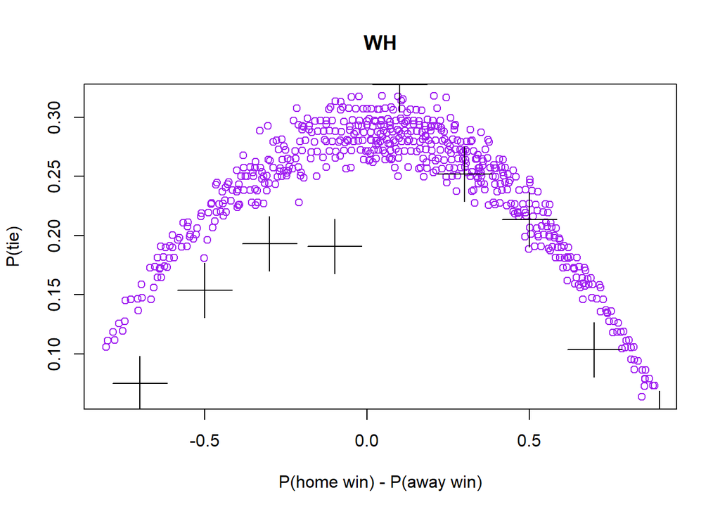

```r
WHH.odd1<-1:828
WHH.odd1[1:380]<-newpl2018$WHH
WHH.odd1[381:760]<-newpl2019$WHH
WHH.odd1[761:828]<-newpl2020$WHH

WHD.oddx<-1:828
WHD.oddx[1:380]<-newpl2018$WHD
WHD.oddx[381:760]<-newpl2019$WHD
WHD.oddx[761:828]<-newpl2020$WHD

WHA.odd2<-1:828
WHA.odd2[1:380]<-newpl2018$WHA
WHA.odd2[381:760]<-newpl2019$WHA
WHA.odd2[761:828]<-newpl2020$WHA

WHH.ph<-1:828
WHH.ph[1:380]<-1/newpl2018$WHH
WHH.ph[381:760]<-1/newpl2019$WHH
WHH.ph[761:828]<-1/newpl2020$WHH

WHD.px<-1:828
WHD.px[1:380]<-1/newpl2018$WHD
WHD.px[381:760]<-1/newpl2019$WHD
WHD.px[761:828]<-1/newpl2020$WHD

WHA.pa<-1:828
WHA.pa[1:380]<-1/newpl2018$WHA
WHA.pa[381:760]<-1/newpl2019$WHA
WHA.pa[761:828]<-1/newpl2020$WHA

NormWHH<-WHH.ph/(WHH.ph+WHD.px+WHA.pa)
NormWHD<-WHD.px/(WHH.ph+WHD.px+WHA.pa)
NormWHA<-WHA.pa/(WHH.ph+WHD.px+WHA.pa)


WH<-data.table(Homescore,Awayscore,Result,WHH.odd1,WHA.odd2,WHD.oddx,WHH.ph,WHA.pa,WHD.px,NormWHH,NormWHA,NormWHD,RedCardH,RedCardA)

WH[,diff:=NormPSH-NormWHA]

br<-(-5:5)/5
bucketWH<-cut(WH$diff,breaks=br,labels=1:10)
WH[,bucket:=bucketWH]

plot(WH$NormWHH-WH$NormWHA,WH$NormWHD,col="purple",main="WH",xlab="P(home win) - P(away win)",ylab="P(tie)")
plot(WH$NormWHH-WH$NormWHA,WH$NormWHD,col="purple",main="WH",xlab="P(home win) - P(away win)",ylab="P(tie)")


whdraws<-1:10
for(i in 1:10)
  whdraws[i]<-sum(WH[bucket==i]$Result=="draw",na.rm=TRUE)


whsum<-1:10
for(i in 1:10)
  whsum[i]<-sum(!is.na(WH[bucket==i]$Result))


whp<-whdraws/whsum
y<-c(-0.9,-0.7,-0.5,-0.3,-0.1,0.1,0.3,0.5,0.7,0.9)
points(y,whp,pch=3,cex = 5)
```

## Using the data I collected after normalizing the data I had before, I constructed the plots of the probability rates of the results of the matches to be tie on the y-axis, compared to difference between probability rates of home win and away win on the x-axis. This operation is repeated for every 4 bookmakers I chose.Then I added the results of every matches as a new column to the every bookmakers’ odd data tables. I constructed buckets from-1 to 1 and numbered them from 1 to 10 in increasing order, each of them corresponding to the value difference between “probability of home win given by a certain bookmaker” - “probability of away win given by a certain bookmaker”. After these operations I calculated the probability of draw results for each bookmakers’ buckets. Then using these calculations I plotted the draw results on the histograms I used above for each bookmaker. It is visible that all bookmakers are negatively biased when x~0 and positively biased when x<0 though with varying degrees.

## TASK 3 FOR BET365

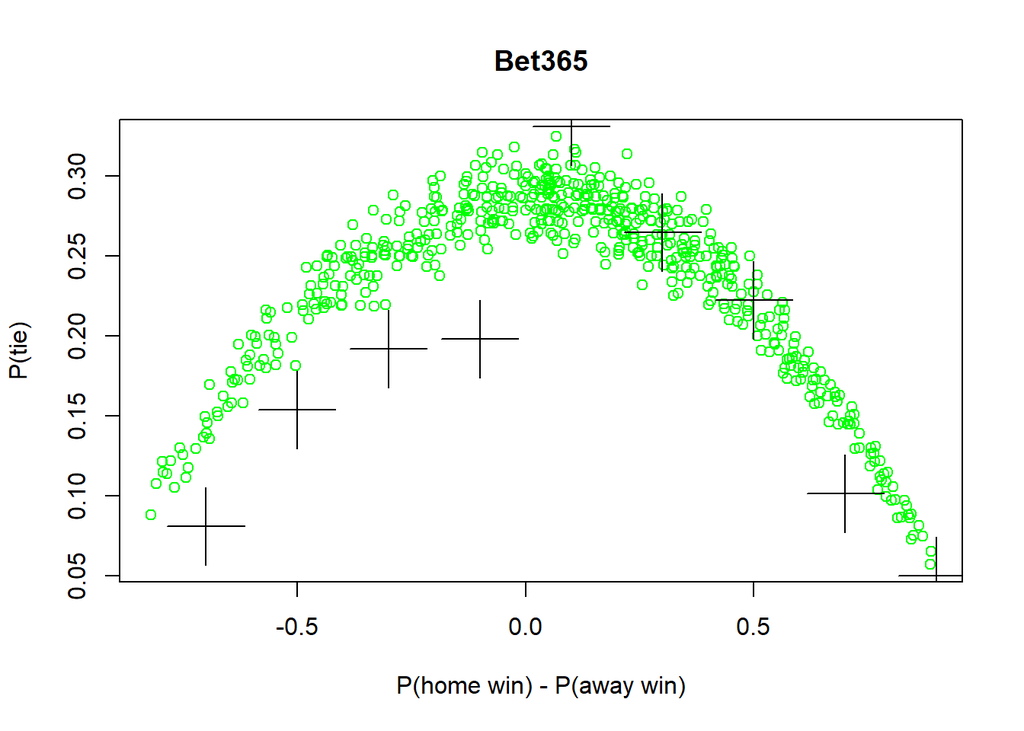

```r
updatedBet365<-filter(Bet365,RedCardH==0 & RedCardA==0)

br<-(-5:5)/5
bucketupdatedBet365<-cut(updatedBet365$diff,breaks=br,labels=1:10)
updatedBet365[,bucket:=bucketupdatedBet365]

plot(updatedBet365$NormBet365H-updatedBet365$NormBet365A,updatedBet365$NormBet365D,col="green",main="Bet365",xlab="P(home win) - P(away win)",ylab="P(tie)")

plot(updatedBet365$NormBet365H-updatedBet365$NormBet365A,updatedBet365$NormBet365D,col="green",main="Bet365",xlab="P(home win) - P(away win)",ylab="P(tie)")

ubet365draws<-1:10
for(i in 1:10)
  ubet365draws[i]<-sum(updatedBet365[bucket==i]$Result=="draw",na.rm=TRUE)


ubet365sum<-1:10
for(i in 1:10)
  ubet365sum[i]<-sum(!is.na(updatedBet365[bucket==i]$Result))


ubet365p<-ubet365draws/ubet365sum
y<-c(-0.9,-0.7,-0.5,-0.3,-0.1,0.1,0.3,0.5,0.7,0.9)
points(y,ubet365p,pch=3,cex = 5)
```

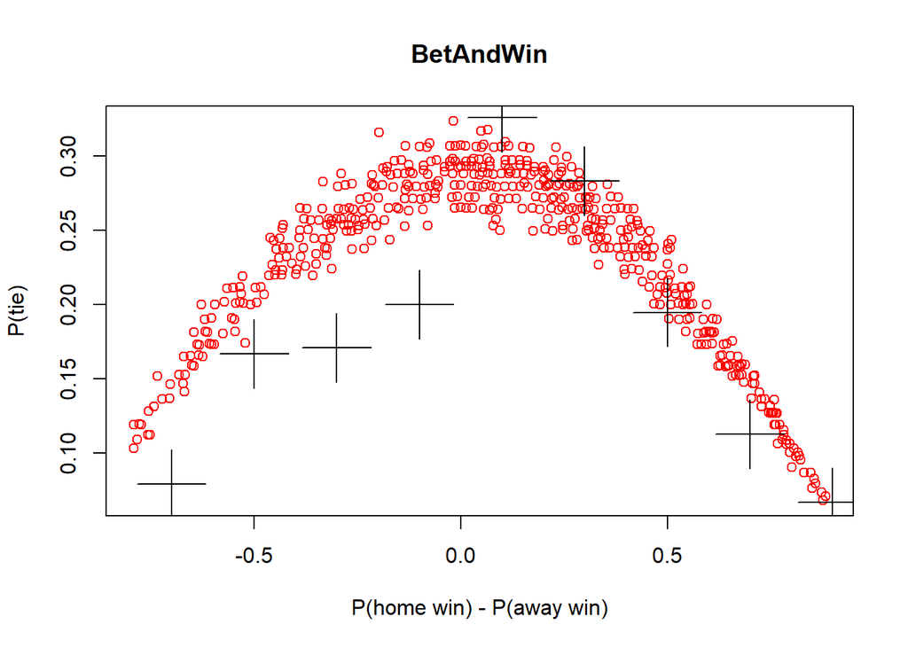

```r
updatedBW<-filter(BW,RedCardH==0 & RedCardA==0)

br<-(-5:5)/5
bucketupdatedBW<-cut(updatedBW$diff,breaks=br,labels=1:10)
updatedBW[,bucket:=bucketupdatedBW]

plot(updatedBW$NormBWH-updatedBW$NormBWA,updatedBW$NormBWD,col="red",main="BetAndWin",xlab="P(home win) - P(away win)",ylab="P(tie)")
plot(updatedBW$NormBWH-updatedBW$NormBWA,updatedBW$NormBWD,col="red",main="BetAndWin",xlab="P(home win) - P(away win)",ylab="P(tie)")

updatedbwdraws<-1:10
for(i in 1:10)
  updatedbwdraws[i]<-sum(updatedBW[bucket==i]$Result=="draw",na.rm=TRUE)


updatedbwsum<-1:10
for(i in 1:10)
  updatedbwsum[i]<-sum(!is.na(updatedBW[bucket==i]$Result))


updatedbwp<-updatedbwdraws/updatedbwsum
y<-c(-0.9,-0.7,-0.5,-0.3,-0.1,0.1,0.3,0.5,0.7,0.9)
points(y,updatedbwp,pch=3,cex = 5)
```

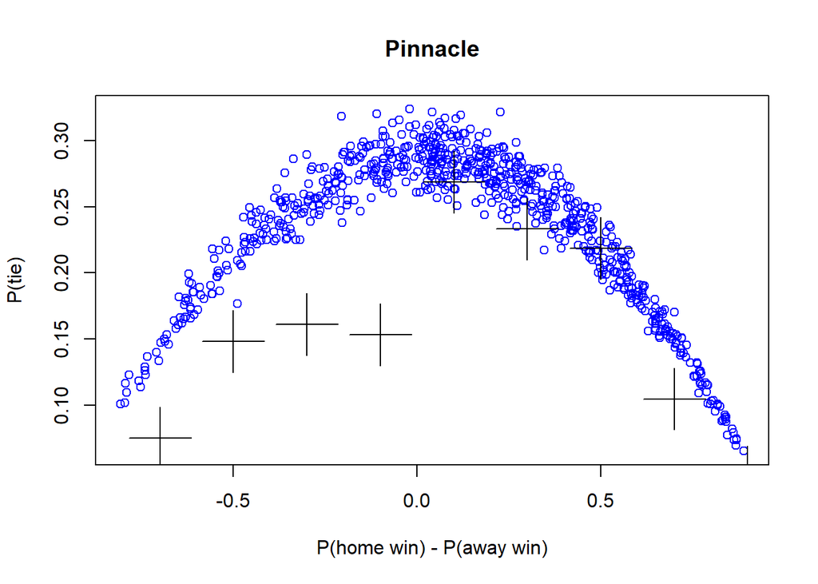

```r
updatedPS<-filter(PS,RedCardH==0 & RedCardA==0)

br<-(-5:5)/5
bucketupdatedPS<-cut(updatedPS$diff,breaks=br,labels=1:10)
updatedPS[,bucket:=bucketupdatedPS]

plot(updatedPS$NormPSH-updatedPS$NormPSA,updatedPS$NormPSD,col="blue",main="Pinnacle",xlab="P(home win) - P(away win)",ylab="P(tie)")
plot(updatedPS$NormPSH-updatedPS$NormPSA,updatedPS$NormPSD,col="blue",main="Pinnacle",xlab="P(home win) - P(away win)",ylab="P(tie)")

updatedpsdraws<-1:10
for(i in 1:10)
  updatedpsdraws[i]<-sum(updatedPS[bucket==i]$Result=="draw",na.rm=TRUE)


updatedpssum<-1:10
for(i in 1:10)
  updatedpssum[i]<-sum(!is.na(PS[bucket==i]$Result))


updatedpsp<-updatedpsdraws/updatedpssum
y<-c(-0.9,-0.7,-0.5,-0.3,-0.1,0.1,0.3,0.5,0.7,0.9)
points(y,updatedpsp,pch=3,cex = 5)
```

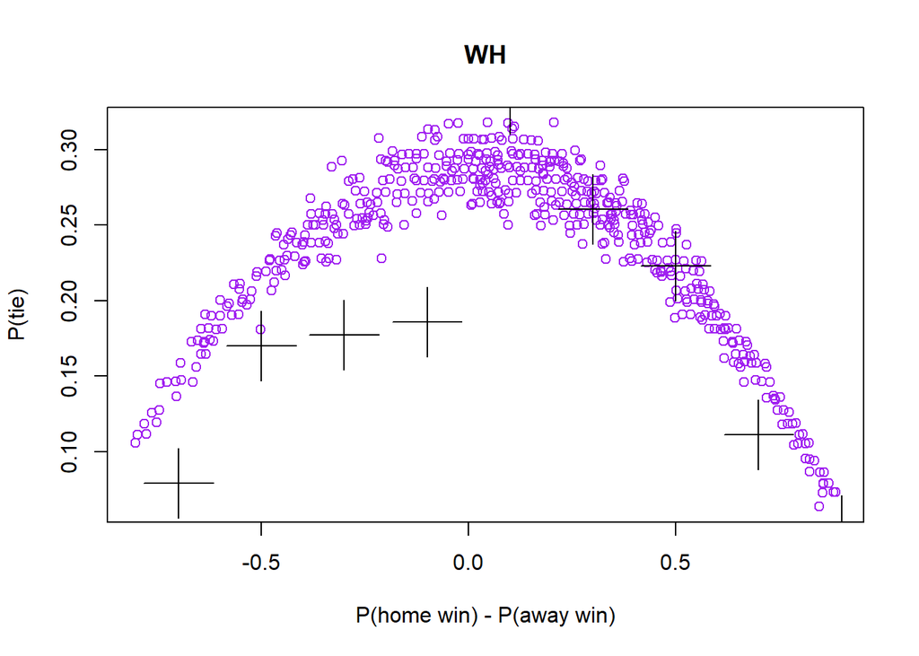

```r
updatedWH<-filter(WH,RedCardH==0 & RedCardA==0)

br<-(-5:5)/5
bucketupdatedWH<-cut(updatedWH$diff,breaks=br,labels=1:10)
updatedWH[,bucket:=bucketupdatedWH]

plot(updatedWH$NormWHH-updatedWH$NormWHA,updatedWH$NormWHD,col="purple",main="WH",xlab="P(home win) - P(away win)",ylab="P(tie)")
plot(updatedWH$NormWHH-updatedWH$NormWHA,updatedWH$NormWHD,col="purple",main="WH",xlab="P(home win) - P(away win)",ylab="P(tie)")



updatedwhdraws<-1:10
for(i in 1:10)
  updatedwhdraws[i]<-sum(updatedWH[bucket==i]$Result=="draw",na.rm=TRUE)


updatedwhsum<-1:10
for(i in 1:10)
  updatedwhsum[i]<-sum(!is.na(updatedWH[bucket==i]$Result))


updatedwhp<-updatedwhdraws/updatedwhsum
y<-c(-0.9,-0.7,-0.5,-0.3,-0.1,0.1,0.3,0.5,0.7,0.9)
points(y,updatedwhp,pch=3,cex = 5)
```